# WhatsApp Group Chat Data Analysis

## Import Required Libraries

```python
import pandas as pd
import numpy as np
import matplotlib.pyplot as plt
import seaborn as sns
import emoji
from collections import Counter
from wordcloud import WordCloud,STOPWORDS
import re
```

## Data Preprocessing

The chat.txt file (exported chat data from one of my active groups in whatsapp) should be in working directory(else complete file location can be given).

```python
data = open("chat.txt",encoding="utf8") # Opening the file with utf8 encoding
string = ' '.join(data.read().split("\n")) # Storing all data in text file into single string.
string[:100] # how does the string look
```

```
'09/01/20, 8:05 pm - Messages and calls are end-to-end encrypted. No one outside of this chat, not ev'
```

```python
date_time_format = "\d{1,2}/\d{1,2}/\d{2,4},\s\d{1,2}:\d{2}\s[apAP][mM]\s-\s"  # Given format of date and time in txt file
date_time = re.findall(date_time_format,string) # finding all date and time with given format and storing into date_time list
message_username =re.split(date_time_format,string) # spliting string with date_time_format as pattern, so only message and username will be stored
date_time[:5]
```

```
['09/01/20, 8:05 pm - ',
 '09/01/20, 8:04 pm - ',
 '09/01/20, 8:05 pm - ',
 '09/01/20, 8:05 pm - ',
 '09/01/20, 8:05 pm - ']
```

```python
message_username[:5]
```

```
['',
 'Messages and calls are end-to-end encrypted. No one outside of this chat, not even WhatsApp, can read or listen to them. Tap to learn more. ',
 'Arun created group "Microcontroller project!!" ',
 'Arun added you ',
 'Arun: Ashi can you write da ']
```

Now need to separate message, username from message_username and convert date_time type from string to datetime format

```python
date_time1 = pd.to_datetime(date_time,format='%d/%m/%y, %I:%M %p - ') # converting given string type into datetime format
date_time1[:5]
```

```
DatetimeIndex(['2020-01-09 20:05:00', '2020-01-09 20:04:00',
               '2020-01-09 20:05:00', '2020-01-09 20:05:00',
               '2020-01-09 20:05:00'],
              dtype='datetime64[ns]', freq=None)
```

```python
user =[]
msg = []
for i in message_username[1:]:
    userMsg = re.split('([\w\W]+?):\s',i)  # user name comes before : and msg Comes after :
    if(userMsg[1:]):
        user.append(userMsg[1])
        msg.append(userMsg[2])
    else:
        user.append("Notif")               # anything other than username is a group notification
        msg.append(userMsg[0])
df = pd.DataFrame({"Date_Time":date_time1,"User":user,"Message":msg})  # Creating a DataFrame with 3 columns date_time, user and Message
df.head()
```

|  | Date_Time | User | Message |
| --- | --- | --- | --- |
| 0 | 2020-01-09 20:05:00 | Notif | Messages and calls are end-to-end encrypted. N... |
| 1 | 2020-01-09 20:04:00 | Notif | Arun created group "Microcontroller project!!" |
| 2 | 2020-01-09 20:05:00 | Notif | Arun added you |
| 3 | 2020-01-09 20:05:00 | Arun | Ashi can you write da |
| 4 | 2020-01-09 20:05:00 | Arun | We will send info |

```python
df.info() # Summary of the dataframe
```

```
<class 'pandas.core.frame.DataFrame'>
RangeIndex: 11443 entries, 0 to 11442
Data columns (total 3 columns):
 #   Column     Non-Null Count  Dtype
---  ------     --------------  -----
 0   Date_Time  11443 non-null  datetime64[ns]
 1   User       11443 non-null  object
 2   Message    11443 non-null  object
dtypes: datetime64[ns](1), object(2)
memory usage: 268.3+ KB
```

## Data Cleaning

```python
df["User"].unique()  #  Rows having Notif is dropped
```

```
array(['Notif', 'Arun', 'Aasiq Vit', 'Aditiya', 'Rajil'], dtype=object)
```

```python
df.drop(df[df["User"]=="Notif"].index,inplace=True)
df.shape
```

```
(11434, 3)
```

```python
df.drop(df[df["Message"]=="<Media omitted> "].index,inplace=True) # Rows having images is dropped
df.shape
```

```
(10294, 3)
```

```python
df.drop(df[df["Message"]=="This message was deleted "].index,inplace=True) # Rows having deleted message can be dropped
df.shape
```

```
(10209, 3)
```

```python
df.info()
```

```
<class 'pandas.core.frame.DataFrame'>
Int64Index: 10209 entries, 3 to 11442
Data columns (total 3 columns):
 #   Column     Non-Null Count  Dtype
---  ------     --------------  -----
 0   Date_Time  10209 non-null  datetime64[ns]
 1   User       10209 non-null  object
 2   Message    10209 non-null  object
dtypes: datetime64[ns](1), object(2)
memory usage: 319.0+ KB
```

```python
df.head()
```

|  | Date_Time | User | Message |
| --- | --- | --- | --- |
| 3 | 2020-01-09 20:05:00 | Arun | Ashi can you write da |
| 4 | 2020-01-09 20:05:00 | Arun | We will send info |
| 5 | 2020-01-09 20:21:00 | Aasiq Vit | Ok da |
| 7 | 2020-01-09 20:28:00 | Aasiq Vit | Dei I can do the writing part da but how can I... |
| 8 | 2020-01-09 20:28:00 | Arun | First four lines abstract da |

```python
df.reset_index(inplace=True,drop=True) # Reseting index
df.head()
```

|  | Date_Time | User | Message |
| --- | --- | --- | --- |
| 0 | 2020-01-09 20:05:00 | Arun | Ashi can you write da |
| 1 | 2020-01-09 20:05:00 | Arun | We will send info |
| 2 | 2020-01-09 20:21:00 | Aasiq Vit | Ok da |
| 3 | 2020-01-09 20:28:00 | Aasiq Vit | Dei I can do the writing part da but how can I... |
| 4 | 2020-01-09 20:28:00 | Arun | First four lines abstract da |

# INSIGHTS

## Active Members to Inactive Members

```python
df.groupby("User")["Message"].count().sort_values(ascending =False)
```

```
User
Rajil        3079
Aditiya      2855
Arun         2327
Aasiq Vit    1948
Name: Message, dtype: int64
```

## Active Time of Group

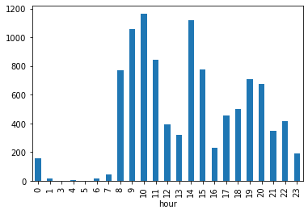

```python
df["hour"]  = df["Date_Time"].apply(lambda x:x.hour) # Creating new col hour from Date_Time Col
df.groupby(["hour"]).size().sort_index().plot(x="hour",kind ="bar") # plotting counts of msg vs each hour
plt.show()
```

This sudden increase from 8th hour says the start of online class, with few breaks in 12 and 13 and there is again sudden increase in 14th hour says the start of LAB section.

## Active Time of Top 4 Active Members in Group

```python
q=df[df["User"]=="Rajil"].groupby(["hour"]).size().sort_index()    # Creating series with index hour and values count
q1=df[df["User"]=="Arun"].groupby(["hour"]).size().sort_index()
q2=df[df["User"]=="Aasiq Vit"].groupby(["hour"]).size().sort_index()
q3=df[df["User"]=="Aditiya"].groupby(["hour"]).size().sort_index()
```

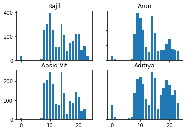

```python
fig, ((ax1, ax2), (ax3, ax4)) = plt.subplots(2, 2) # 2 X 2 matrix subplots
ax1.bar(q.index,q.values)
ax1.set_title("Rajil")                             # Adding titles
ax2.bar(q1.index,q1.values)
ax2.set_title("Arun")
ax3.bar(q2.index,q2.values)
ax3.set_title("Aasiq Vit")
ax4.bar(q3.index,q3.values)
ax4.set_title("Aditiya")
for ax in fig.get_axes():
    ax.label_outer()                              # Labelling only for outer graphs
plt.show()
```

## Before vs During Lockdown Trends

```python
df["Date"] = pd.to_datetime(df["Date_Time"].apply(lambda x:x.date()))  # Creating new col Date from Date_Time
df.head()
```

|  | Date_Time | User | Message | hour | Date |
| --- | --- | --- | --- | --- | --- |
| 0 | 2020-01-09 20:05:00 | Arun | Ashi can you write da | 20 | 2020-01-09 |
| 1 | 2020-01-09 20:05:00 | Arun | We will send info | 20 | 2020-01-09 |
| 2 | 2020-01-09 20:21:00 | Aasiq Vit | Ok da | 20 | 2020-01-09 |
| 3 | 2020-01-09 20:28:00 | Aasiq Vit | Dei I can do the writing part da but how can I... | 20 | 2020-01-09 |
| 4 | 2020-01-09 20:28:00 | Arun | First four lines abstract da | 20 | 2020-01-09 |

```python
Lockdown_Date = pd.to_datetime("2020-03-21")  # LOCKDOWN started and my cllg preponded summer holidays
mask = Lockdown_Date > df["Date"]             # Comparing with all Dates
mask
```

```
0         True
1         True
2         True
3         True
4         True
         ...
10204    False
10205    False
10206    False
10207    False
10208    False
Name: Date, Length: 10209, dtype: bool
```

Separating DataFrames into Before and After Lockdown

```python
df1 = df[mask].copy()   # Before Lockdown
df2 = df[~mask].copy()      # After Lockdown
df1.shape
```

```
(1350, 6)
```

```python
df2.shape
```

```
(8859, 6)
```

Average msgs per day

```python
df1.groupby("Date")["Message"].count()
```

```
Date
2020-01-09     19
2020-01-10      7
2020-01-11     25
2020-01-12     45
2020-01-13     25
2020-01-15     12
2020-01-16     17
2020-01-17      7
2020-01-18      1
2020-01-19      2
2020-01-25     45
2020-01-26      5
2020-01-27     32
2020-01-28      8
2020-01-29      6
2020-01-30     54
2020-02-03      2
2020-02-06      7
2020-02-10      8
2020-02-11     15
2020-02-12      8
2020-02-13      1
2020-02-14     28
2020-02-15     19
2020-02-16     11
2020-02-17     56
2020-02-18      1
2020-02-19     22
2020-02-20      3
2020-02-21     34
2020-02-22     10
2020-02-23      3
2020-02-24     36
2020-02-25     16
2020-02-26     18
2020-02-27     11
2020-02-29     86
2020-03-01    141
2020-03-02     31
2020-03-03     68
2020-03-04      4
2020-03-05    108
2020-03-06      8
2020-03-07     20
2020-03-08     30
2020-03-09      1
2020-03-10     56
2020-03-11     26
2020-03-12     26
2020-03-13     35
2020-03-14     20
2020-03-15     44
2020-03-16     11
2020-03-17      2
2020-03-18      6
2020-03-19      7
2020-03-20      1
Name: Message, dtype: int64
```

Average message per day before lockdown

```python
sum(df1.groupby("Date")["Message"].count())/df1.groupby("Date")["Message"].count().size
```

```
23.68421052631579
```

Average message per day during lockdown

```python
sum(df2.groupby("Date")["Message"].count())/df2.groupby("Date")["Message"].count().size
```

```
74.4453781512605
```

DURING LOCKDOWN

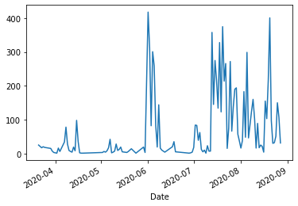

```python
df2.groupby("Date")["Message"].count().plot()
plt.show()
```

The spike in start of june month indicates the VITOL exam preparation, and the one starts in middle of July indicates the Start of FALL Semester and all other stable lines are holidays

BEFORE LOCKDOWN

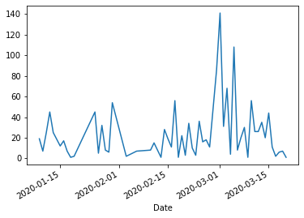

```python
df1.groupby("Date")["Message"].count().plot()
plt.show()
```

Week days Trends before Lockdown and During Lockdown

```python
df["weekday"] = df["Date_Time"].apply(lambda x : x.day_name()) # Adding weekday column
```

```python
df.head()
```

|  | Date_Time | User | Message | hour | Date | weekday |
| --- | --- | --- | --- | --- | --- | --- |
| 0 | 2020-01-09 20:05:00 | Arun | Ashi can you write da | 20 | 2020-01-09 | Thursday |
| 1 | 2020-01-09 20:05:00 | Arun | We will send info | 20 | 2020-01-09 | Thursday |
| 2 | 2020-01-09 20:21:00 | Aasiq Vit | Ok da | 20 | 2020-01-09 | Thursday |
| 3 | 2020-01-09 20:28:00 | Aasiq Vit | Dei I can do the writing part da but how can I... | 20 | 2020-01-09 | Thursday |
| 4 | 2020-01-09 20:28:00 | Arun | First four lines abstract da | 20 | 2020-01-09 | Thursday |

Overall count plot

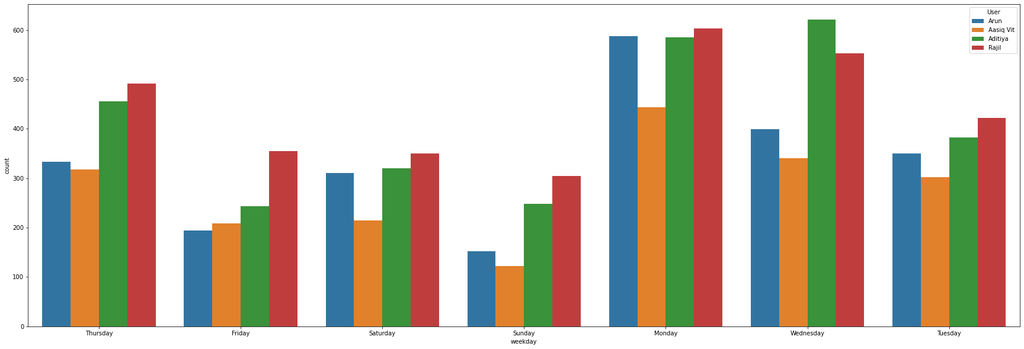

```python
plt.figure(figsize=(30,10))
sns.countplot(x = "weekday",hue="User",data=df)
plt.show()
```

### Plot For Before Lockdown

```python
df1["weekday"] = df1["Date_Time"].apply(lambda x : x.day_name())
df1.head()
```

|  | Date_Time | User | Message | hour | Date | weekday |
| --- | --- | --- | --- | --- | --- | --- |
| 0 | 2020-01-09 20:05:00 | Arun | Ashi can you write da | 20 | 2020-01-09 | Thursday |
| 1 | 2020-01-09 20:05:00 | Arun | We will send info | 20 | 2020-01-09 | Thursday |
| 2 | 2020-01-09 20:21:00 | Aasiq Vit | Ok da | 20 | 2020-01-09 | Thursday |
| 3 | 2020-01-09 20:28:00 | Aasiq Vit | Dei I can do the writing part da but how can I... | 20 | 2020-01-09 | Thursday |
| 4 | 2020-01-09 20:28:00 | Arun | First four lines abstract da | 20 | 2020-01-09 | Thursday |

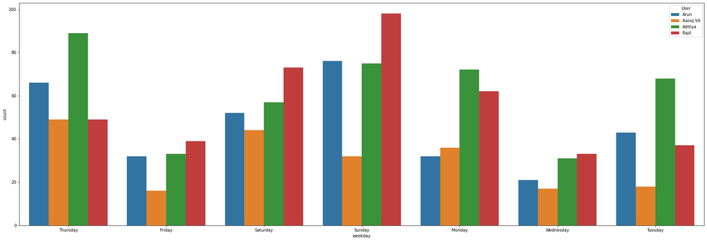

```python
plt.figure(figsize=(30,10))
sns.countplot(x = "weekday",hue="User",data=df1)
plt.show()
```

Since Saturday and Sunday are holidays, its contributing more than weekdays (we directly meeting in weekdays)

### Plot for During Lockdown

```python
df2["weekday"] = df2["Date_Time"].apply(lambda x : x.day_name())
df2.head()
```

|  | Date_Time | User | Message | hour | Date | weekday |
| --- | --- | --- | --- | --- | --- | --- |
| 1350 | 2020-03-21 12:54:00 | Aditiya | https://youtu.be/lKbPx8NZEb0 | 12 | 2020-03-21 | Saturday |
| 1351 | 2020-03-21 12:55:00 | Aditiya | Another good episode | 12 | 2020-03-21 | Saturday |
| 1352 | 2020-03-21 19:29:00 | Aditiya | seen this? | 19 | 2020-03-21 | Saturday |
| 1353 | 2020-03-21 19:30:00 | Aditiya | ethana vaati da trouble shooting? | 19 | 2020-03-21 | Saturday |
| 1354 | 2020-03-21 19:31:00 | Rajil | 😂 | 19 | 2020-03-21 | Saturday |

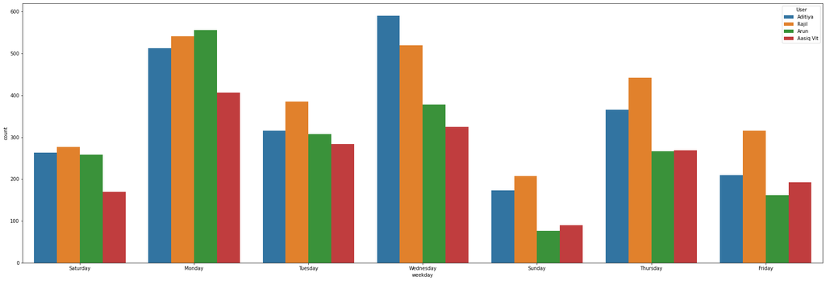

```python
plt.figure(figsize=(30,10))
sns.countplot(x = "weekday",hue="User",data=df2)
plt.show()
```

All Other days except Sunday is contributing more as there is online class monday to saturday

## Reply Messages

```python
msg_index = np.array(df[df["User"]=="Rajil"].index) # finding index array of my msgs
msg_index,msg_index.shape
```

```
(array([   29,    32,    36, ..., 10206, 10207, 10208], dtype=int64), (3079,))
```

```python
prev_msg_index = msg_index-1             # previous msg index
post_msg_index = msg_index+1             # post msg insex
prev_msg_index,prev_msg_index.shape,post_msg_index,post_msg_index.shape
```

```
(array([   28,    31,    35, ..., 10205, 10206, 10207], dtype=int64),
 (3079,),
 array([   30,    33,    37, ..., 10207, 10208, 10209], dtype=int64),
 (3079,))
```

```python
post_msg_index = post_msg_index[:-1]     # discarding the last value inoder to avoid out of index error
```

```python
df_replied_by_me = df.iloc[prev_msg_index].copy()   # Dataframe consisting msg previous to my msg
df_replied_to_me = df.iloc[post_msg_index].copy()   # Dataframe consisting msg after to my msg
```

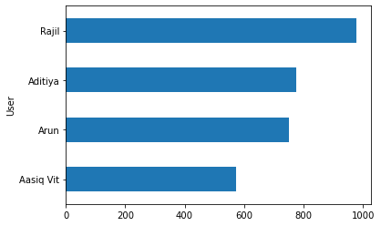

```python
df_replied_by_me.groupby(["User"])["Message"].size().sort_values().plot(kind="barh")
plt.show()
```

Considering the fact of continuous messages, I replied to Aditiya most of times

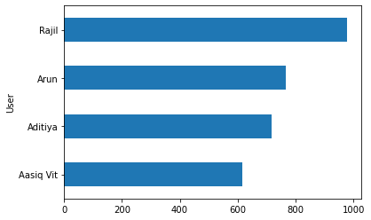

```python
df_replied_to_me.groupby(["User"])["Message"].size().sort_values().plot(kind="barh")
plt.show()
```

This says Arun Replied to me most of the times

## Playing with Words

```python
def word_count(string):     # function for apply to find count of words
    return len(string.split())
```

```python
df["no_of_words"] = df["Message"].apply(word_count) # New col no_of_words containing the same
df.head()
```

|  | Date_Time | User | Message | hour | Date | weekday | no_of_words |
| --- | --- | --- | --- | --- | --- | --- | --- |
| 0 | 2020-01-09 20:05:00 | Arun | Ashi can you write da | 20 | 2020-01-09 | Thursday | 5 |
| 1 | 2020-01-09 20:05:00 | Arun | We will send info | 20 | 2020-01-09 | Thursday | 4 |
| 2 | 2020-01-09 20:21:00 | Aasiq Vit | Ok da | 20 | 2020-01-09 | Thursday | 2 |
| 3 | 2020-01-09 20:28:00 | Aasiq Vit | Dei I can do the writing part da but how can I... | 20 | 2020-01-09 | Thursday | 16 |
| 4 | 2020-01-09 20:28:00 | Arun | First four lines abstract da | 20 | 2020-01-09 | Thursday | 5 |

```python
df.groupby("User")["no_of_words"].sum().sort_values(ascending = False)  # Who used more words to least words
```

```
User
Rajil        14458
Arun         10329
Aasiq Vit    10272
Aditiya       9921
Name: no_of_words, dtype: int64
```

### No. of Words used per message

```python
(df.groupby("User")["no_of_words"].sum()/df.groupby("User").size()).sort_values(ascending=False)
```

```
User
Aasiq Vit    5.273101
Rajil        4.695680
Arun         4.438762
Aditiya      3.474956
dtype: float64
```

## Frequently used Emojis

```python
emoji_ctr = Counter()
emojis_list = map(lambda x: ''.join(x.split()), emoji.UNICODE_EMOJI.keys())
r = re.compile('|'.join(re.escape(p) for p in emojis_list))
for idx, row in df.iterrows():
    emojis_found = r.findall(row["Message"])
    for emoji_found in emojis_found:
        emoji_ctr[emoji_found] += 1
```

```python
for item in emoji_ctr.most_common(10):   # considering only top 10 emmojis
    print(item[0] + " - " + str(item[1]))
```

```
😂 - 658
😭 - 62
👍 - 42
🤣 - 37
🔥 - 19
✌ - 18
🤦‍♂ - 18
😅 - 16
🤷‍♂ - 14
🏻 - 10
```

### Frequently used emojis for each member

```python
def ema(user1):            # Function for emoji and its count
    emoji_ctr = Counter()
    emojis_list = map(lambda x: ''.join(x.split()),emoji.UNICODE_EMOJI.keys())
    r = re.compile('|'.join(re.escape(p) for p in emojis_list))
    for idx,row in df.iterrows():
        if row["User"] == user1:
            emoji_found = r.findall(row["Message"])
            for emoji_found in emoji_found:
                emoji_ctr[emoji_found]+=1
    for item in emoji_ctr.most_common(10):
        print(item[0]+" - "+str(item[1]))
```

```python
for i in df["User"].unique():
    print(i+" : ")
    ema(i)
    print("\n")
```

```
Arun :
😂 - 318
🤣 - 30
😭 - 26
👍 - 20
🏻 - 8
😁 - 5
🔥 - 5
😄 - 4
🤔 - 4
😫 - 3


Aasiq Vit :
😂 - 26
🤣 - 5
😭 - 2
😎 - 2
🦠 - 1
🌐 - 1
😨 - 1
✋ - 1
😶 - 1
👍 - 1


Aditiya :
😂 - 64
✌ - 18
🤦‍♂ - 14
😭 - 14
🤷‍♂ - 11
😅 - 8
🔥 - 7
😒 - 6
💵 - 5
👆 - 4


Rajil :
😂 - 250
👍 - 20
😭 - 20
🙌 - 9
😅 - 7
🔥 - 7
👌 - 4
🤦‍♂ - 4
🤷‍♂ - 3
😱 - 2
```

## Frequently used Words

```python
Stop_words = set(STOPWORDS)   # Stopwords to overcome most common words used in english
Stop_words = STOPWORDS.update(["}","{","<<","int","nu",",","u","=","lol","yeah","yea","ok","1","okay","na","seri","illa","ya","da",
                               "iruku","is","will","one","la","ah","dhan","the","in","to","i","?"]) # updating with few that we used commonly
```

```python
T=[]
for string in df["Message"].values:
    string = string.lower()
    words_list =string.split()  # creating a list of words in each msg
    for words in words_list:
        if words not in STOPWORDS:   # for each words which is not in stopwords is appended to T
            T.append(words)
```

```python
Frequent_Words = pd.Series(Counter(T)).sort_values(ascending=False)  # Making a series with counter of each word and word
```

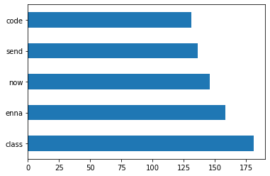

```python
Frequent_Words[:5].plot(kind="barh") # Ploting the top 5 frequently used words
plt.show()
```

```python
q={}
for i in df["User"].unique():
    T=[]
    for string in df[df["User"]==i]["Message"].values:
        string = string.lower()
        words_list =string.split()
        for words in words_list:
            if words not in STOPWORDS:
                T.append(words)
    Frequent_Words = pd.Series(Counter(T)).sort_values(ascending=False)
    q[i] = Frequent_Words[:5]  # Similary making a Series for top 4 active user
```

Ploting the top 5 Frequently used words for each user

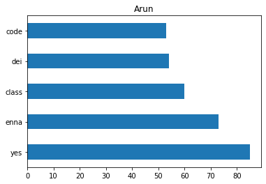

```python
plt.title("Arun")
q["Arun"].plot(kind="barh")
plt.show()
```

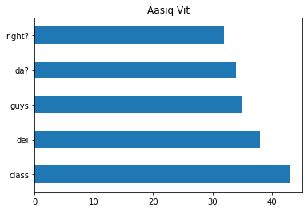

```python
plt.title("Aasiq Vit")
q["Aasiq Vit"].plot(kind="barh")
plt.show()
```

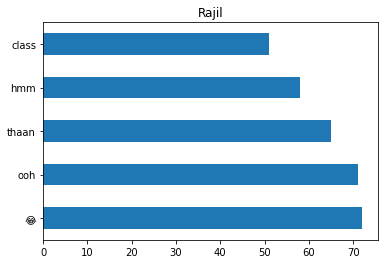

```python
plt.title("Rajil")
q["Rajil"].plot(kind="barh")
plt.show()
```

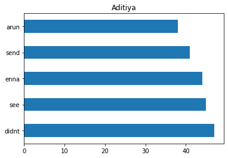

```python
plt.title("Aditiya")
q["Aditiya"].plot(kind="barh")
plt.show()
```

## Frequently used words in WordCloud form

```python
Frequent_Words = ""
for string in df["Message"].values:
    string = string.lower()
    words_list =string.split()
    for words in words_list:
        Frequent_Words  =Frequent_Words+ words +" "
wordcloud = WordCloud(width = 900, height = 700,background_color ='black',stopwords = Stop_words,
                      min_font_size = 8).generate(Frequent_Words)
```

[figure not shown]

```python
wordcloud.to_image()
```

### This image can be stored as any image format by

```python
wordcloud.to_file("FrequentWords.png")
```

```
<wordcloud.wordcloud.WordCloud at 0x1e06a180448>
```